# Stat 135: Lab Project

# Part 4: Testing

## Question 1:

There are two good ways to test if males and females are equally exposed to Type II diabetes. The first way is the chi-square test of homogeneity.

To do this test, let's first split our data into their 4 respective cells.

```r
female.diabetics = length(which(data$gender=="female" & data$glyhb >= 7))
female.nondiabetics = length(which(data$gender=="female" & data$glyhb < 7))

male.diabetics = length(which(data$gender=="male" & data$glyhb >= 7))
male.nondiabetics = length(which(data$gender=="male" & data$glyhb < 7))

gender.mat = matrix(c(male.diabetics, male.nondiabetics, female.diabetics,
                      female.nondiabetics), nrow=2, dimnames=list(c("Diabetic",
                      "Not Diabetic"), c("Male", "Female")))
gender.mat
```

```r
##              Male Female
## Diabetic       24     30
## Not Diabetic  125    180
```

Now let's run our chi-square test.

```r
chisq.test(gender.mat)
```

```r
##
##  Pearson's Chi-squared test with Yates' continuity correction
##
## data:  gender.mat
## X-squared = 0.1062, df = 1, p-value = 0.7445
```

With one degree of freedom and a chi-square statistic of 0.1062, we get a p-value of 0.7445 and fail to reject the null hypothesis that males and females are equally exposed to type-II diabetes.

Now we will use our second way which is an equal means test of 2 proportions.

First we will need to convert data sets into 0s and 1s:

```r
female.df = data[data$gender=="female",]
female.diab.status = vector()
  for (i in 1:nrow(female.df)){
  if (female.df$glyhb[i]>=7) {female.diab.status[i]=1
  } else female.diab.status[i]=0
}

male.df = data[data$gender=="male",]
male.diab.status = vector()
for (i in 1:nrow(male.df)){
  if (male.df$glyhb[i]>=7) {male.diab.status[i]=1
  } else male.diab.status[i]=0
}
```

Now we will run the t-test.

```r
t.test(female.diab.status, male.diab.status, alternative="two.sided", mu=0,
       paired=FALSE, var.equal=FALSE, conf.level=0.95)
```

```r
##
##  Welch Two Sample t-test
##
## data:  female.diab.status and male.diab.status
## t = -0.4705, df = 308.83, p-value = 0.6383
## alternative hypothesis: true difference in means is not equal to 0
## 95 percent confidence interval:
##  -0.09439683  0.05796347
## sample estimates:
## mean of x mean of y
## 0.1428571 0.1610738
```

Using a two-sample t-test for proportions, we get a p-value of 0.6383 and fail to reject the null hypothesis that males and females are equally exposed to type-II diabetes.

So, both of our tests failed to reject the null.

## Question 2:

Our five favorite features are: stabilized glucose, age, first systolic blood pressure, BMI, and WHR.

First, let's make vectors subsetted by our features and store them in a list.

```r
groupList = list()

# Stabilized glucose level:
stab.gluc.diabetic = data[data$glyhb>=7, 4]
stab.gluc.nondiabetic = data[data$glyhb<7, 4]

groupList[[1]] = stab.gluc.diabetic
groupList[[2]] = stab.gluc.nondiabetic

# Age:
age.diabetic = data[data$glyhb>=7, 9]
age.nondiabetic = data[data$glyhb<7, 9]

groupList[[3]] = age.diabetic
groupList[[4]] = age.nondiabetic

# First systolic blood pressure:
bp.1s.diabetic = data[data$glyhb>=7, 14]
bp.1s.nondiabetic = data[data$glyhb<7, 14]

groupList[[5]] = bp.1s.diabetic
groupList[[6]] = bp.1s.nondiabetic

# BMI:
bmi.diabetic = data[data$glyhb>=7, 20]
bmi.nondiabetic = data[data$glyhb<7, 20]

groupList[[7]] = bmi.diabetic
groupList[[8]] = bmi.nondiabetic

# WHR:
whr.diabetic = data[data$glyhb>=7, 21]
whr.nondiabetic = data[data$glyhb<7, 20]

groupList[[9]] = whr.diabetic
groupList[[10]] = whr.nondiabetic
```

Let's check for normality of samples means for each group to see if parametric t-tests are appropriate.

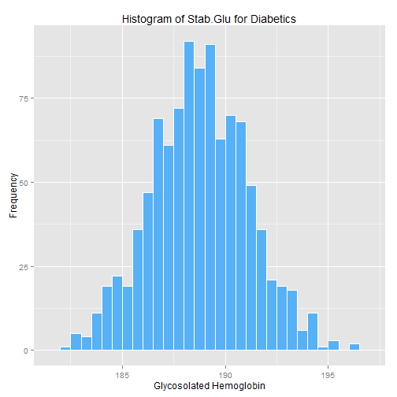

```r
plot.boot.hist = function(x){
  boot.pop = replicate(1000, sample(x, 1000, replace=TRUE))
  boot.pop.means = apply(boot.pop, 2, mean)
  return(boot.pop.means)
}

pop_means = data.frame(sapply(groupList, plot.boot.hist))

# Stab.glu of diabetics
ggplot(pop_means) + geom_histogram(aes(x = pop_means[ , 1]), binwidth = 0.5, col = "white", fill = "#56B1F7") +
  ggtitle("Histogram of Stab.Glu for Diabetics") +
  xlab("Glycosolated Hemoglobin") + ylab("Frequency")
```

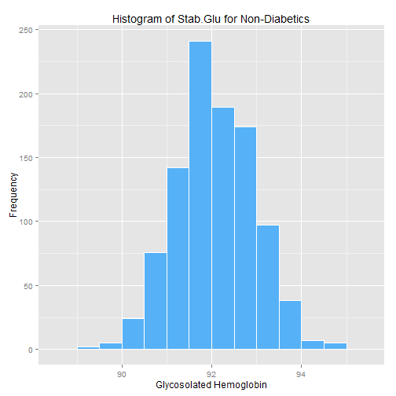

```r
# Stab.glu of non-diabetics
ggplot(pop_means) + geom_histogram(aes(x = pop_means[ , 2]), binwidth = 0.5, col = "white", fill = "#56B1F7") +
  ggtitle("Histogram of Stab.Glu for Non-Diabetics") +
  xlab("Glycosolated Hemoglobin") + ylab("Frequency")
```

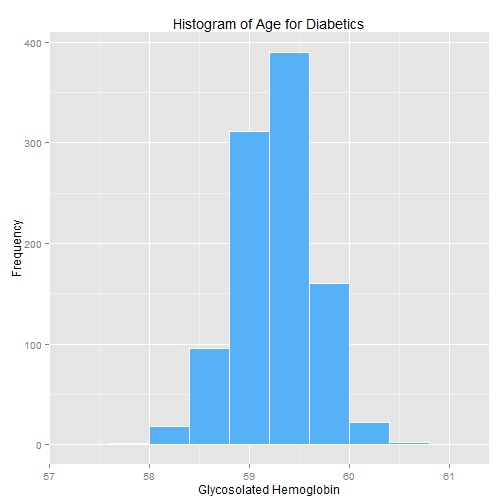

```r
# Age of diabetics
ggplot(pop_means) + geom_histogram(aes(x = pop_means[ , 3]), binwidth = 0.4, col = "white", fill = "#56B1F7") +
  ggtitle("Histogram of Age for Diabetics") +
  xlab("Glycosolated Hemoglobin") + ylab("Frequency")
```

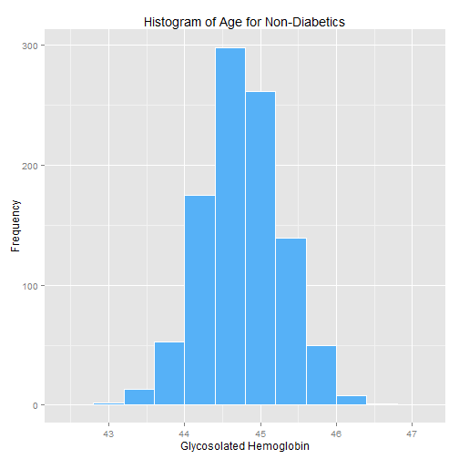

```r
# Age of non-diabetics
ggplot(pop_means) + geom_histogram(aes(x = pop_means[ , 4]), binwidth = 0.4, col = "white", fill = "#56B1F7") +
  ggtitle("Histogram of Age for Non-Diabetics") +
  xlab("Glycosolated Hemoglobin") + ylab("Frequency")
```

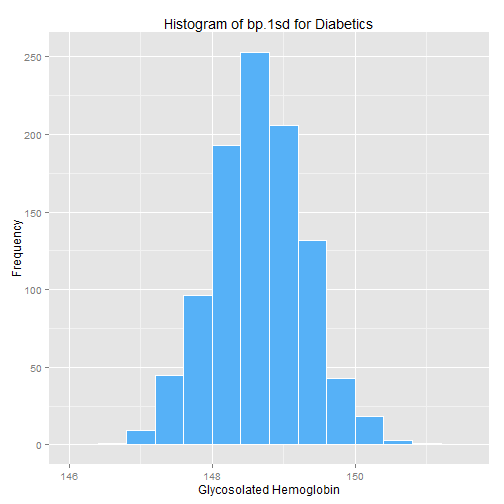

```r
# bp.1sd of diabetics
ggplot(pop_means) + geom_histogram(aes(x = pop_means[ , 5]), binwidth = 0.4, col = "white", fill = "#56B1F7") +
  ggtitle("Histogram of bp.1sd for Diabetics") +
  xlab("Glycosolated Hemoglobin") + ylab("Frequency")
```

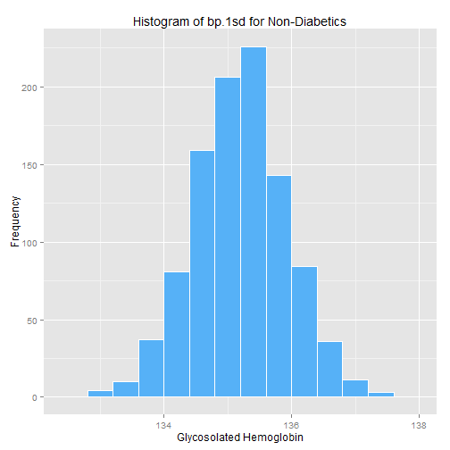

```r
# bp.1sd of non-diabetics
ggplot(pop_means) + geom_histogram(aes(x = pop_means[ , 6]), binwidth = 0.4, col = "white", fill = "#56B1F7") +
  ggtitle("Histogram of bp.1sd for Non-Diabetics") +
  xlab("Glycosolated Hemoglobin") + ylab("Frequency")
```

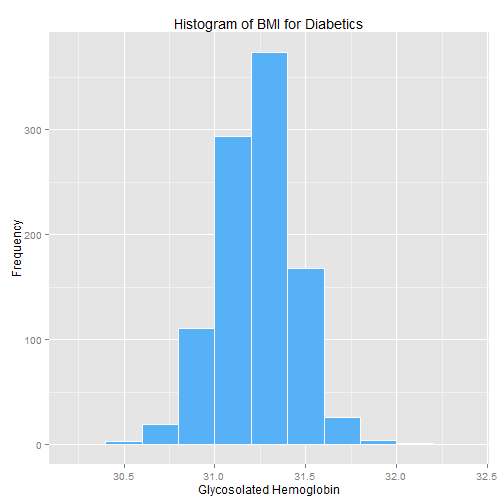

```r
# BMI of diabetics
ggplot(pop_means) + geom_histogram(aes(x = pop_means[ , 7]), binwidth = 0.2, col = "white", fill = "#56B1F7") +
  ggtitle("Histogram of BMI for Diabetics") +
  xlab("Glycosolated Hemoglobin") + ylab("Frequency")
```

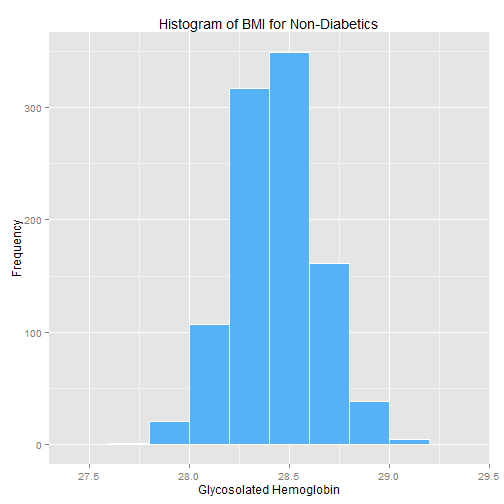

```r
# BMI of non-diabetics
ggplot(pop_means) + geom_histogram(aes(x = pop_means[ , 8]), binwidth = 0.2, col = "white", fill = "#56B1F7") +
  ggtitle("Histogram of BMI for Non-Diabetics") +
  xlab("Glycosolated Hemoglobin") + ylab("Frequency")
```

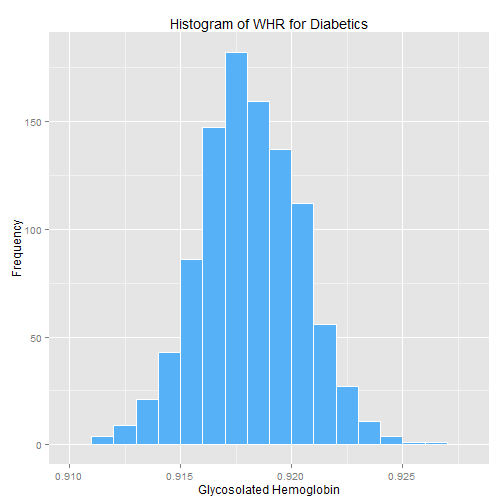

```r
# WHR of diabetics
ggplot(pop_means) + geom_histogram(aes(x = pop_means[ , 9]), binwidth = 0.001, col = "white", fill = "#56B1F7") +
  ggtitle("Histogram of WHR for Diabetics") +
  xlab("Glycosolated Hemoglobin") + ylab("Frequency")
```

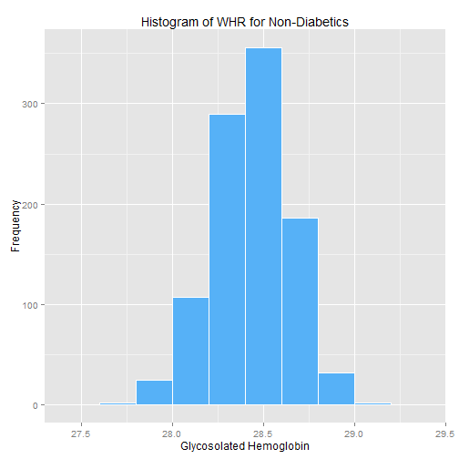

```r
# WHR of non-diabetics
ggplot(pop_means) + geom_histogram(aes(x = pop_means[ , 10]), binwidth = 0.20, col = "white", fill = "#56B1F7") +
  ggtitle("Histogram of WHR for Non-Diabetics") +
  xlab("Glycosolated Hemoglobin") + ylab("Frequency")
```

All of these histograms look approximately normal, so we can use t-tests.

```r
t.test(stab.gluc.diabetic, stab.gluc.nondiabetic, alternative="two.sided", mu=0,
       paired=FALSE, var.equal=FALSE, conf.level=0.95)
```

```r
##
##  Welch Two Sample t-test
##
## data:  stab.gluc.diabetic and stab.gluc.nondiabetic
## t = 9.3067, df = 55.536, p-value = 6.257e-13
## alternative hypothesis: true difference in means is not equal to 0
## 95 percent confidence interval:
##   75.99568 117.69455
## sample estimates:
## mean of x mean of y
##  188.9074   92.0623
```

```r
t.test(age.diabetic, age.nondiabetic, alternative="two.sided", mu=0,
       paired=FALSE, var.equal=FALSE, conf.level=0.95)
```

```r
##
##  Welch Two Sample t-test
##
## data:  age.diabetic and age.nondiabetic
## t = 7.1981, df = 84.628, p-value = 2.302e-10
## alternative hypothesis: true difference in means is not equal to 0
## 95 percent confidence interval:
##  10.49031 18.49803
## sample estimates:
## mean of x mean of y
##  59.27778  44.78361
```

```r
t.test(bp.1s.diabetic, bp.1s.nondiabetic, alternative="two.sided", mu=0,
       paired=FALSE, var.equal=FALSE, conf.level=0.95)
```

```r
##
##  Welch Two Sample t-test
##
## data:  bp.1s.diabetic and bp.1s.nondiabetic
## t = 4.3315, df = 77.595, p-value = 4.384e-05
## alternative hypothesis: true difference in means is not equal to 0
## 95 percent confidence interval:
##   7.24591 19.57400
## sample estimates:
## mean of x mean of y
##  148.6296  135.2197
```

```r
t.test(bmi.diabetic, bmi.nondiabetic, alternative="two.sided", mu=0,
       paired=FALSE, var.equal=FALSE, conf.level=0.95)
```

```r
##
##  Welch Two Sample t-test
##
## data:  bmi.diabetic and bmi.nondiabetic
## t = 2.919, df = 74.596, p-value = 0.00464
## alternative hypothesis: true difference in means is not equal to 0
## 95 percent confidence interval:
##  0.8891927 4.7122889
## sample estimates:
## mean of x mean of y
##  31.22315  28.42241
```

```r
t.test(whr.diabetic, whr.nondiabetic, alternative="two.sided", mu=0,
       paired=FALSE, var.equal=FALSE, conf.level=0.95)
```

```r
##
##  Welch Two Sample t-test
##
## data:  whr.diabetic and whr.nondiabetic
## t = -71.6995, df = 304.418, p-value < 2.2e-16
## alternative hypothesis: true difference in means is not equal to 0
## 95 percent confidence interval:
##  -28.25904 -26.74934
## sample estimates:
##  mean of x  mean of y
##  0.9182154 28.4224085
```

For all of these features, we reject the null hypothesis that the means for those with and for those without diabetes are equal.